# Korelace

Klíčové pojmy:

- kovariance
- korelace

#### Kovariance

Kovariance je definována jako $cov(X, Y) = E[(X-E[X])(Y-E[Y])]$. Pokud máme kardinální proměnnou pocházející z výběru o velikosti $n$, pak lze kovarianci vypočítat jako $cov(X, Y) = \frac{1}{n-1}\sum_i^n(x_i - \bar{x})(y_i-\bar{y})$. Kovariance tak představuje výpočet společné variability obou proměnných. Můžeme si ji také představit jako výpočet toho, jak moc se velké hodnoty jedné proměnné shodují s velkými hodnotami druhé proměnné. Jako “velkou hodnotu” rozumíme její kladnou odchylku od průměru a jako “malou hodnotu” rozumíme její negativní odchylku od průměru. Protože jako “velkou/malou hodnotu” měříme rozdíl od průměru měří kovariance míru lineární závislosti mezi dvěma proměnnými.

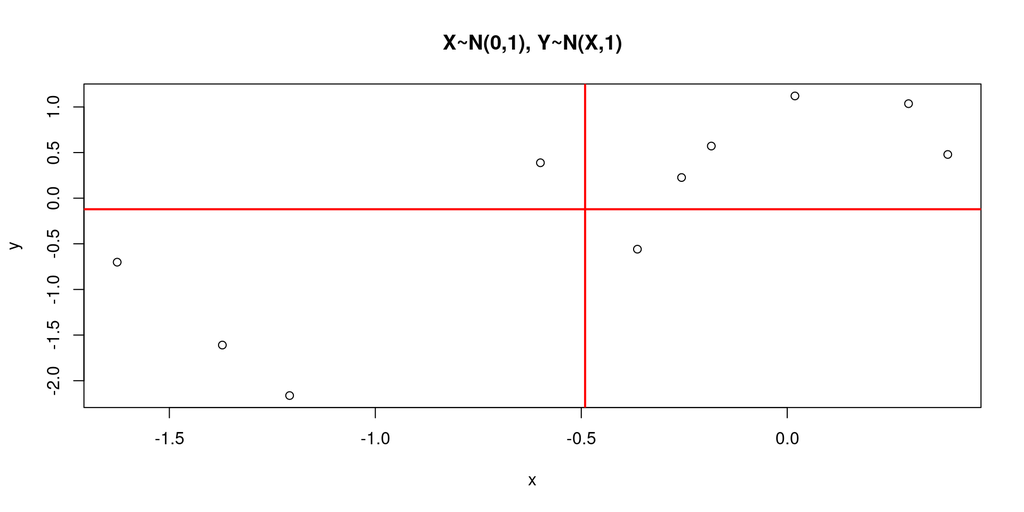

```r
set.seed(10)
n <- 10
x <- rnorm(n)
y <- rnorm(n, mean = x)

plot(x,y, main = "X~N(0,1), Y~N(X,1)")
abline(v = mean(x), col = "red", lwd = 2)
abline(h = mean(y), col = "red", lwd = 2)
```

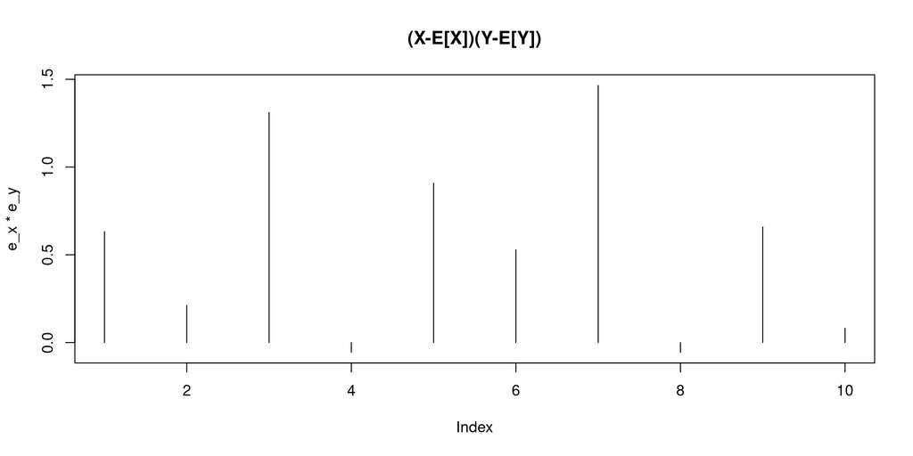

```r
e_x <- x - mean(x)
e_y <- y - mean(y)

plot(e_x*e_y, type = "h", main = "(X-E[X])(Y-E[Y])")
```

```r
cov_xy <- sum(e_x*e_y) / n #nebo take mean(e_x*e_y)
print(cov_xy)
```

```
## [1] 0.5686958
```

Zkuste odpovědět na následující otázky:

1. za jakých podmínek bude číslo pozitivní?
2. za jakých podmínek bude číslo nezitivní?
3. za jakých podmínek bude číslo zhruba 0?

V R můžeme vypočítat $cov(X,Y)$ pomocí funkce `cov`. Podobně jako u směrodatné odchylky nebo rozptylu počítá R s populační kovariencí, tedy dělíme $n-1$ místo $n$.

```r
cov(x,y)
```

```
## [1] 0.6318843
```

Zkuste si nyní sami nasimulovat situace, v kterých bude kovariance:

1. negativní,
2. zhruba rovná 0

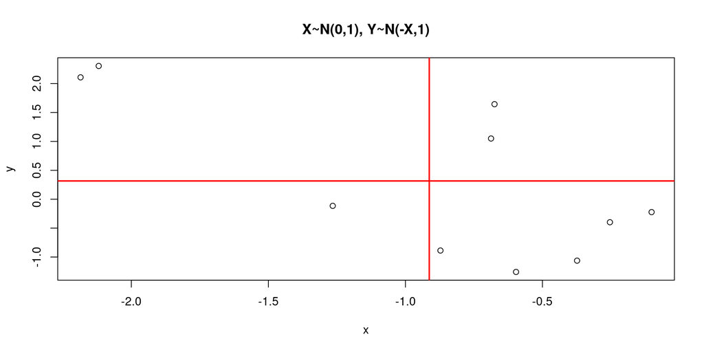

```r
# negativni
n <- 10
x <- rnorm(n)
y <- rnorm(n, mean = -1*x)

plot(x,y, main = "X~N(0,1), Y~N(-X,1)")
abline(v = mean(x), col = "red", lwd = 2)
abline(h = mean(y), col = "red", lwd = 2)
```

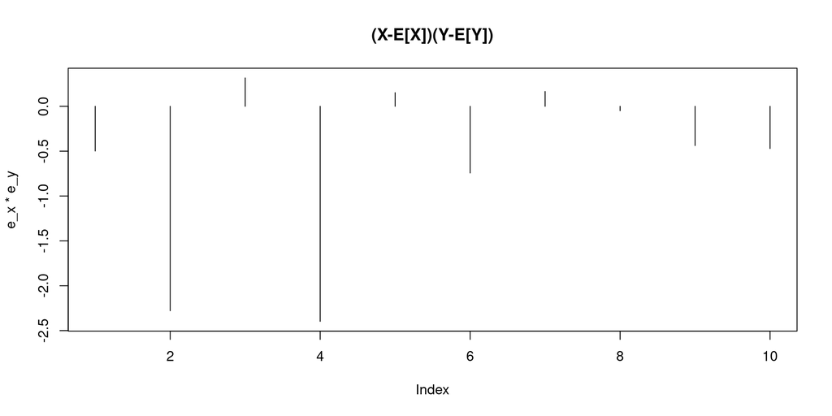

```r
e_x <- x - mean(x)
e_y <- y - mean(y)

plot(e_x*e_y, type = "h", main = "(X-E[X])(Y-E[Y])")
```

```r
cov_xy <- sum(e_x*e_y) / n #nebo take mean(e_x*e_y)
print(cov_xy)
```

```
## [1] -0.6241691
```

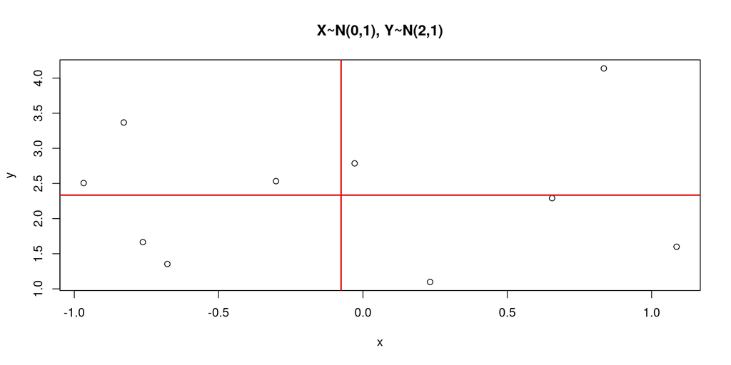

```r
# zhruba 0
x <- rnorm(n)
y <- rnorm(n, mean = 2)

plot(x,y, main = "X~N(0,1), Y~N(2,1)")
abline(v = mean(x), col = "red", lwd = 2)
abline(h = mean(y), col = "red", lwd = 2)
```

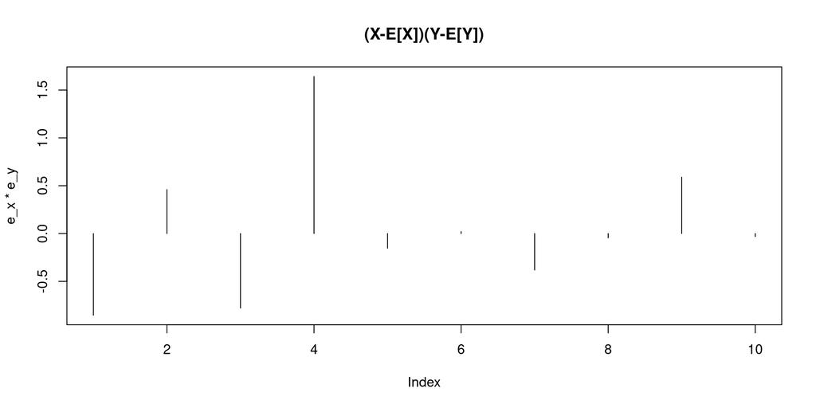

```r
e_x <- x - mean(x)
e_y <- y - mean(y)

plot(e_x*e_y, type = "h", main = "(X-E[X])(Y-E[Y])")
```

```r
cov_xy <- sum(e_x*e_y) / n #nebo take mean(e_x*e_y)
print(cov_xy)
```

```
## [1] 0.04690166
```

Hodnota kovariance není teoreticky ohraničena a tedy $cov(X,Y) = (-\infty; \infty)$. Toto není moc praktické, pokud chceme kovariance porovnávat mezi sebou. Proto při výpočtu pearsonova korelačního koeficientu kovarianci standardizujeme tak, že ji vydělíme produktem směrodatné odchylky obou proměnných, tedy $\rho_{xy} = \frac{\frac{\sum_i^n(x_i - \bar{x})(y_i-\bar{y})}{n}}{\sigma_x\sigma_y}$, nebo po pokrácení $n$ také, $\rho_{xy} = \frac{\sum_i^n(x_i - \bar{x})(y_i-\bar{y})}{\sqrt{\sum_i^n(x_i - \bar{x})^2}\sqrt{\sum_i^n(y_i - \bar{y})^2}}$. Tento korelační koeficient $\rho$ je mezi -1 a 1. Přičemž -1 znamena perfektně lineárně negativní vztah a 1 znamena perfektně lineárně pozitivní vztah. Hodnota 0 znamena, že mezi proměnnými není žádný lineární vztah. Vypočítejme si korelační koeficient pro náš první příklad.

```r
set.seed(10)
n <- 10
x <- rnorm(n)
y <- rnorm(n, mean = x)
e_x <- x - mean(x)
e_y <- y - mean(y)
r <- sum(e_x * e_y) / (sqrt(sum(e_x^2)) * sqrt(sum(e_y^2)))
print(r)
```

```
## [1] 0.8161314
```

Můžeme také použít funkci `cor`.

```r
cor(x,y)
```

```
## [1] 0.8161314
```

Jak jsme si ukázali u kovariance, tento výpočet měří míru lineární závislosti. Pokud tedy funkce (vztah), mezi proměnnými není lineární (ale očividně tam nějaký vztah je), pearsonův korelační koeficient není nejlepším způsobem jak vyjádřit vztah mezi proměnnými.

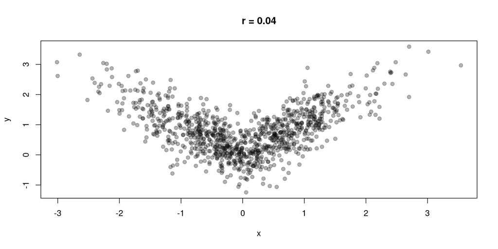

```r
n <- 1000
x <- rnorm(n)
y <- ifelse(x > 0, rnorm(n, x, sd = 0.5), rnorm(n, -1*x, sd = 0.5))
r <- cor(x,y)
plot(x,y,
     main = paste0("r = ", round(r, 2)),
     pch = 19,
     col = adjustcolor("black", alpha.f = 0.3))
```

Pearsonův korelační koeficient je také velmi náchylný na odlehlá pozorování. To jsou taková pozorování, která nabývají výrazně jiných hodnot, než většina pozorování dané proměnné.

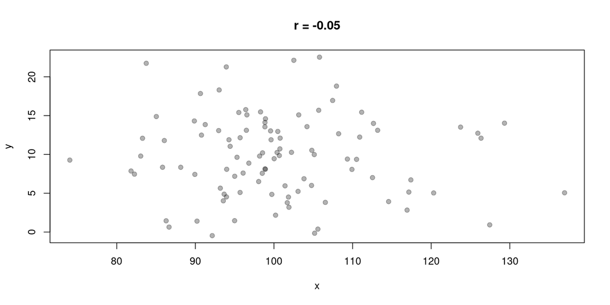

```r
# vytvorime dve nezavisle promenne
n <- 100
x <- rnorm(n, mean = 100, sd = 10)
y <- rnorm(n, mean = 10, sd = 5)
r <- cor(x,y)
plot(x,y,
     main = paste0("r = ", round(r, 2)),
     pch = 19,
     col = adjustcolor("black", alpha.f = 0.3))
```

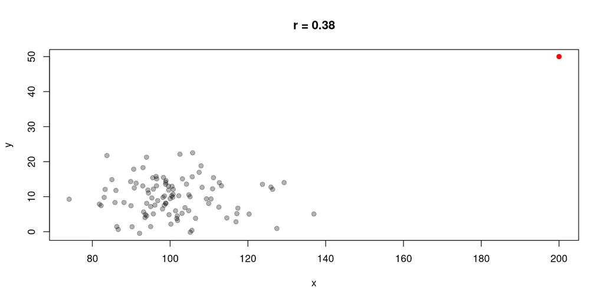

```r
# pridame jedno extremni pozorovani
x <- c(x, 200)
y <- c(y, 50)
r <- cor(x,y)
plot(x,y,
     main = paste0("r = ", round(r, 2)),
     pch = 19,
     col = adjustcolor("black", alpha.f = 0.3))
points(x[101], y[101], col = "red", pch = 19)
```

Stejně tak může málo odlehlých hodnot “vymazat” existijící lineární vztah

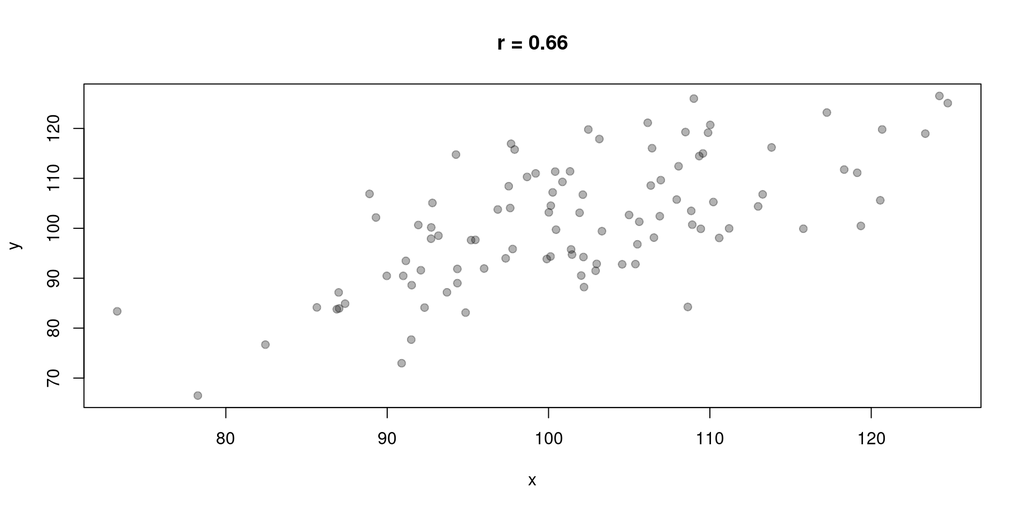

```r
# vytvorime dve zavisle promenne
n <- 100
x <- rnorm(n, mean = 100, sd = 10)
y <- rnorm(n, x, sd = 10)
r <- cor(x,y)
plot(x,y,
     main = paste0("r = ", round(r, 2)),
     pch = 19,
     col = adjustcolor("black", alpha.f = 0.3))
```

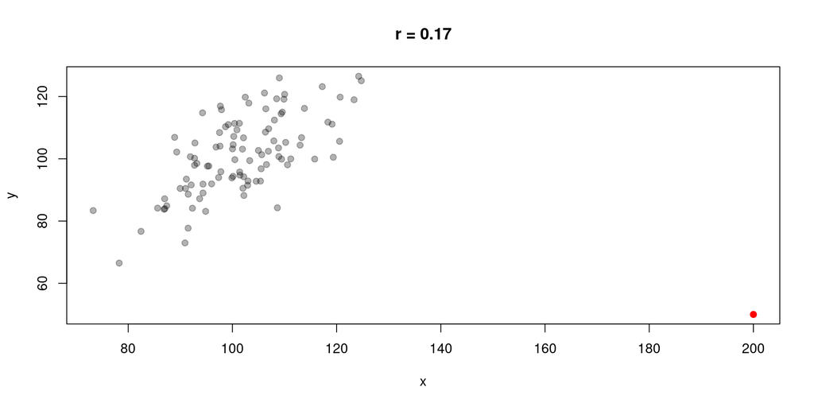

```r
# pridame jedno extremni pozorovani
x <- c(x, 200)
y <- c(y, 50)
r <- cor(x,y)
plot(x,y,
     main = paste0("r = ", round(r, 2)),
     pch = 19,
     col = adjustcolor("black", alpha.f = 0.3))
points(x[101], y[101], col = "red", pch = 19)
```

Proto je vždy nutné si vztah obou proměnných zobrazit v grafu!